# Value of diamonds

Lovdip Singh

## Question of interest/goal of the study

We want to check the power relationship between the colour and their price per carat. In particular, we want want to estimate how much 50% increase in colour score affects the price of the diamonds.

## Read in and inspect the data:

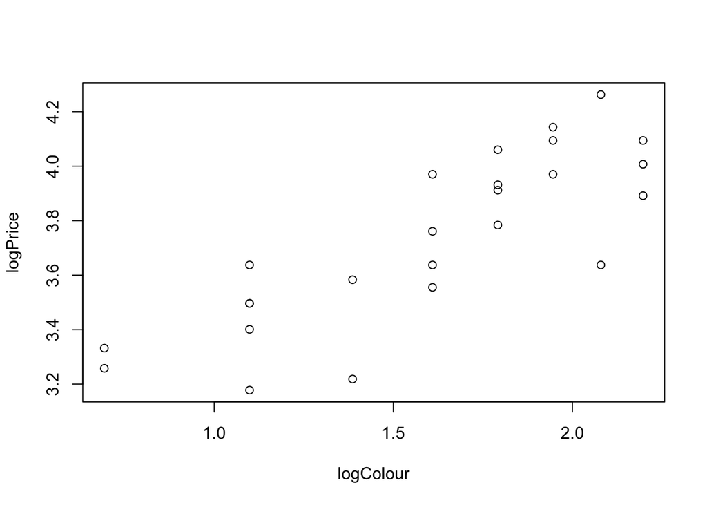

```r
diamonds.df=read.csv("Diamonds.csv")

diamonds.df$logPrice=log(diamonds.df$Price)
diamonds.df$logColour=log(diamonds.df$Colour)

plot(logPrice~logColour,data=diamonds.df)
```

Logging the explanatory and response numerical variables, colour and price, respectively, shows a positive linear relationship with fairly constant scatter. This suggest that a power law model explaining the logged variables is appropriate.

## Fit model and check assumptions.

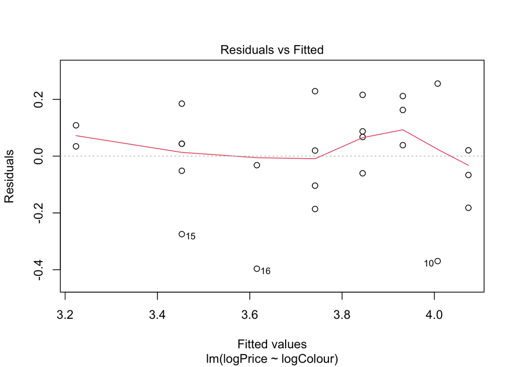

```r
diamonds.fit <- lm(logPrice ~ logColour, data=diamonds.df)

plot(diamonds.fit, which=1)
```

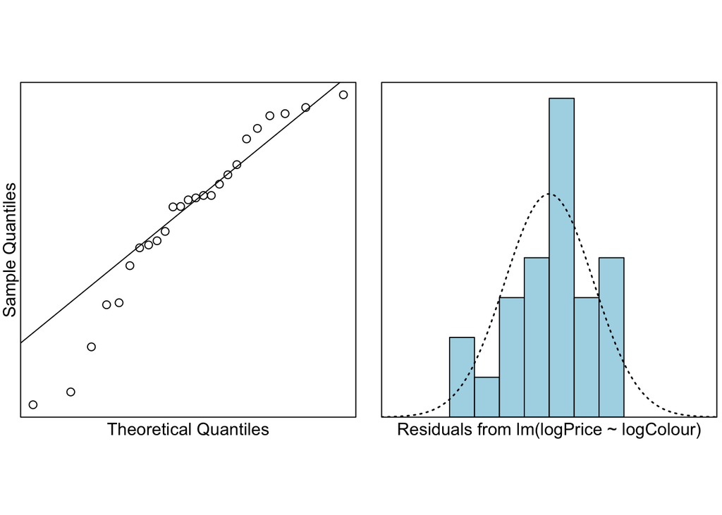

```r
normcheck(diamonds.fit)
```

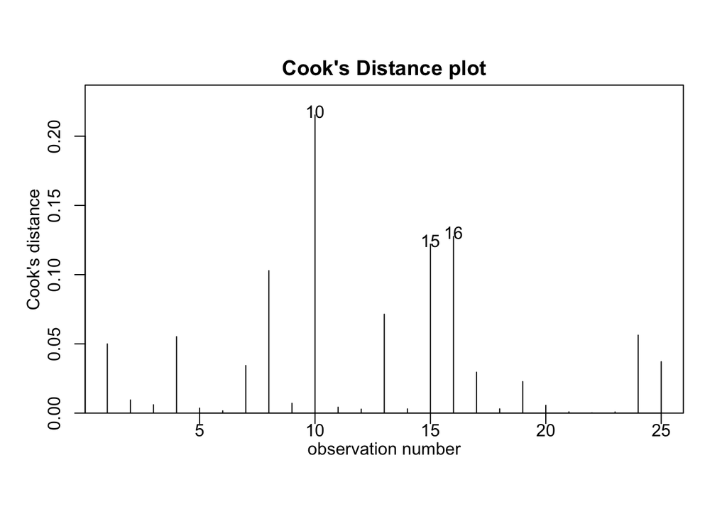

```r
cooks20x(diamonds.fit)
```

```r
summary(diamonds.fit)
```

```
##
## Call:
## lm(formula = logPrice ~ logColour, data = diamonds.df)
##
## Residuals:
##      Min       1Q   Median       3Q      Max
## -0.39651 -0.06642  0.03449  0.10860  0.25550
##
## Coefficients:
##             Estimate Std. Error t value Pr(>|t|)
## (Intercept)  2.83181    0.13425  21.093  < 2e-16 ***
## logColour    0.56523    0.08109   6.971 4.18e-07 ***
## ---
## Signif. codes:  0 '***' 0.001 '**' 0.01 '*' 0.05 '.' 0.1 ' ' 1
##
## Residual standard error: 0.1818 on 23 degrees of freedom
## Multiple R-squared:  0.6787, Adjusted R-squared:  0.6648
## F-statistic: 48.59 on 1 and 23 DF,  p-value: 4.184e-07
```

```r
confint(diamonds.fit)[2, ]  #1% increase
```

```
##     2.5 %    97.5 %
## 0.3974912 0.7329698
```

```r
1.5^confint(diamonds.fit)[2, ]  #50% increase
```

```
##    2.5 %   97.5 %
## 1.174883 1.346076
```

## Method and Assumption Checks

After logging the variables, the plot showed a positive linear relationship between log(price) and log(colour). A power law model was then fitted explaining log(price) with log(colour).

The residual plot did show some concerns, and the normality assumption was hindered, however the sample size of this data was quite small, indicating the assumption is likely to hold given a larger sample size. There were no unduly influential points.

Our final model is:

$log(price_i) =\beta_0 +\beta_1\times log(colour_i) +\epsilon_i$, Or

$price_i =e^{\beta_0} \times colour_i^{\beta_1} +\epsilon_i$

where $\epsilon_i \sim iid ~ N(0,\sigma^2)$

Our power law model explained 67.9% of the variability in log(price).

## Executive summary

We wanted find if the power relationship between price and colour holds. The linearity of the logged data suggests that this power relationship does hold. From our data, $\alpha$ and $\beta$ from the believed power model, $Price = \alpha \times Colour^\beta$, are $e^{2.83}$ and $0.565$, respectively.

We estimate that a 1% increase in colour score corresponds to an increase in the median price of a diamond between 0.4% to 0.73%. For a 50% increase in colour score, we estimate the median price of a diamond to increase between 17.5% to 34.6%.